# Overview

This report presents the Phase 11 analytical and visualization outputs for the Fraud Detection System internship project.

The analysis uses compact aggregated datasets generated from the processed PaySim dataset.

The project follows the internship methodology:

**Ask → Prepare → Process → Analyze → Share → Act**

This report contributes to the **Share** stage by communicating fraud-related findings through tables and visualizations.

# Data Summary

```r
library(readr)
library(dplyr)
library(ggplot2)
library(tidyr)

data_dir <- file.path("..", "data", "visualization")

summary_data <- read_csv(
  file.path(data_dir, "fraud_summary.csv"),
  show_col_types = FALSE
)

by_type <- read_csv(
  file.path(data_dir, "fraud_by_type.csv"),
  show_col_types = FALSE
)

by_step <- read_csv(
  file.path(data_dir, "fraud_by_step.csv"),
  show_col_types = FALSE
)

by_amount <- read_csv(
  file.path(data_dir, "fraud_by_amount.csv"),
  show_col_types = FALSE
)

model_performance <- read_csv(
  file.path(data_dir, "model_performance.csv"),
  show_col_types = FALSE
)

summary_data
```

```
## # A tibble: 8 × 2
##   metric                        value
##   <chr>                         <dbl>
## 1 Total Transactions         6.36e+ 6
## 2 Fraud Transactions         8.21e+ 3
## 3 Legitimate Transactions    6.35e+ 6
## 4 Fraud Rate (%)             1.29e- 1
## 5 Total Transaction Amount   1.14e+12
## 6 Average Transaction Amount 1.80e+ 5
## 7 Minimum Transaction Amount 0
## 8 Maximum Transaction Amount 9.24e+ 7
```

# Fraud by Transaction Type

The transaction-type analysis compares the number of transactions and fraud rate associated with each transaction category.

```r
by_type %>%
  arrange(desc(fraud_rate_percent))
```

```
## # A tibble: 5 × 4
##   transaction_type total_transactions fraud_transactions fraud_rate_percent
##   <chr>                         <dbl>              <dbl>              <dbl>
## 1 TRANSFER                     532909               4097              0.769
## 2 CASH_OUT                    2237500               4116              0.184
## 3 CASH_IN                     1399284                  0              0
## 4 DEBIT                         41432                  0              0
## 5 PAYMENT                     2151495                  0              0
```

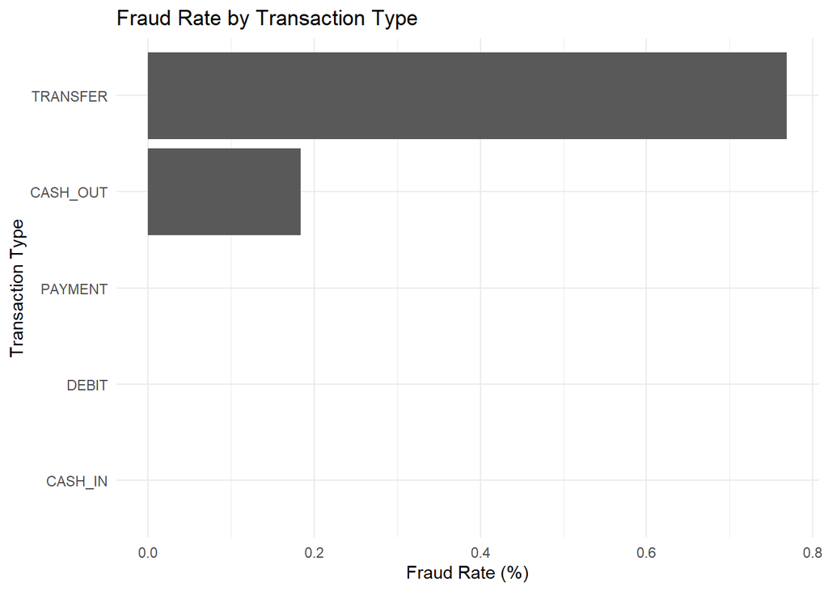

```r
ggplot(
  by_type,
  aes(
    x = reorder(transaction_type, fraud_rate_percent),
    y = fraud_rate_percent
  )
) +
  geom_col() +
  coord_flip() +
  labs(
    title = "Fraud Rate by Transaction Type",
    x = "Transaction Type",
    y = "Fraud Rate (%)"
  ) +
  theme_minimal()
```

# Fraud Across Simulation Steps

The PaySim dataset contains simulation steps that can be used to investigate how fraud activity changes throughout the simulated period.

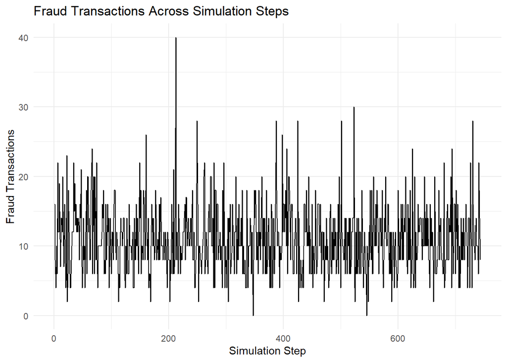

```r
ggplot(
  by_step,
  aes(
    x = step,
    y = fraud_transactions
  )
) +
  geom_line() +
  labs(
    title = "Fraud Transactions Across Simulation Steps",
    x = "Simulation Step",
    y = "Fraud Transactions"
  ) +
  theme_minimal()
```

# Transaction Amount Analysis

Transaction amounts are grouped into ranges so that the distribution can be communicated without exposing the complete transaction-level dataset.

```r
by_amount %>%
  arrange(amount_order)
```

```
## # A tibble: 10 × 5
##    amount_bin        total_transactions fraud_transactions fraud_rate_percent
##    <chr>                          <dbl>              <dbl>              <dbl>
##  1 0-100                          14105                 18            0.128
##  2 1,000,001+                    130626               2706            2.07
##  3 1,001-5,000                   559855                104            0.0186
##  4 10,001-50,000                1519856                760            0.0500
##  5 100,001-500,000              2497038               2642            0.106
##  6 101-500                        56987                 34            0.0597
##  7 5,001-10,000                  583590                116            0.0199
##  8 50,001-100,000                719351                669            0.0930
##  9 500,001-1,000,000             209658               1158            0.552
## 10 501-1,000                      71554                  6            0.00839
## # ℹ 1 more variable: amount_order <dbl>
```

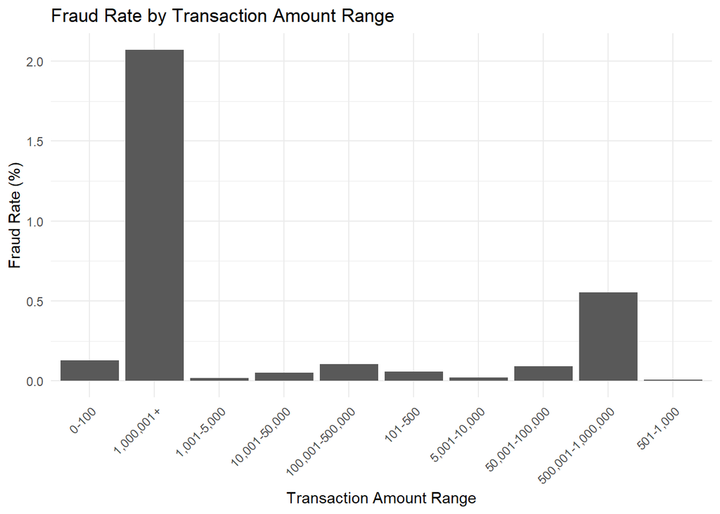

```r
ggplot(
  by_amount,
  aes(
    x = reorder(amount_bin, amount_order),
    y = fraud_rate_percent
  )
) +
  geom_col() +
  labs(
    title = "Fraud Rate by Transaction Amount Range",
    x = "Transaction Amount Range",
    y = "Fraud Rate (%)"
  ) +
  theme_minimal() +
  theme(
    axis.text.x = element_text(
      angle = 45,
      hjust = 1
    )
  )
```

# Model Comparison

The Phase 8 model comparison provides the model-performance evidence used in this visualization stage.

```r
model_performance
```

```
## # A tibble: 4 × 6
##   model               accuracy precision recall f1_score roc_auc
##   <chr>                  <dbl>     <dbl>  <dbl>    <dbl>   <dbl>
## 1 Random Forest          1.000    0.999   0.998   0.998    0.999
## 2 Autoencoder           NA        0.0858  0.722   0.153    0.944
## 3 Logistic Regression    0.967    0.0341  0.894   0.0658   0.984
## 4 Isolation Forest      NA        0.0353  0.270   0.0624   0.894
```

```r
model_long <- model_performance %>%
  select(
    model,
    precision,
    recall,
    f1_score,
    roc_auc
  ) %>%
  pivot_longer(
    cols = c(
      precision,
      recall,
      f1_score,
      roc_auc
    ),
    names_to = "metric",
    values_to = "score"
  )

model_long
```

```
## # A tibble: 16 × 3
##    model               metric     score
##    <chr>               <chr>      <dbl>
##  1 Random Forest       precision 0.999
##  2 Random Forest       recall    0.998
##  3 Random Forest       f1_score  0.998
##  4 Random Forest       roc_auc   0.999
##  5 Autoencoder         precision 0.0858
##  6 Autoencoder         recall    0.722
##  7 Autoencoder         f1_score  0.153
##  8 Autoencoder         roc_auc   0.944
##  9 Logistic Regression precision 0.0341
## 10 Logistic Regression recall    0.894
## 11 Logistic Regression f1_score  0.0658
## 12 Logistic Regression roc_auc   0.984
## 13 Isolation Forest    precision 0.0353
## 14 Isolation Forest    recall    0.270
## 15 Isolation Forest    f1_score  0.0624
## 16 Isolation Forest    roc_auc   0.894
```

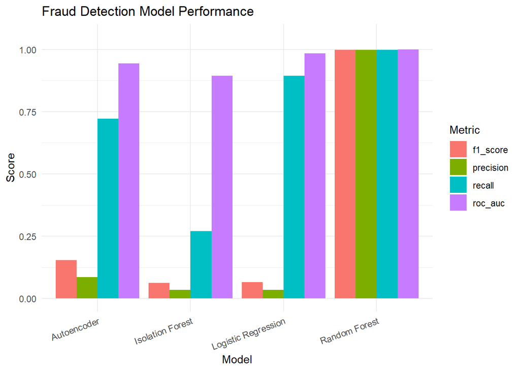

```r
ggplot(
  model_long,
  aes(
    x = model,
    y = score,
    fill = metric
  )
) +
  geom_col(position = "dodge") +
  labs(
    title = "Fraud Detection Model Performance",
    x = "Model",
    y = "Score",
    fill = "Metric"
  ) +
  ylim(0, 1.05) +
  theme_minimal() +
  theme(
    axis.text.x = element_text(
      angle = 20,
      hjust = 1
    )
  )
```

# Findings

The visualization stage focuses on communicating the analytical findings rather than creating additional machine-learning models.

The following areas are emphasized:

1. Overall fraud prevalence.
2. Differences in fraud rates between transaction types.
3. Changes in fraud activity across simulation steps.
4. Differences in fraud rates across transaction amount ranges.
5. Comparative model performance using precision, recall, F1-score, and ROC-AUC.

The Phase 8 model comparison identified Random Forest as the strongest overall supervised approach in the evaluated results.

The anomaly-detection models remain important because they demonstrate alternative approaches to fraud detection.

# Limitations

The PaySim dataset is synthetic and therefore the visual findings should not be interpreted as production banking behaviour.

The visualizations communicate patterns in the project dataset and do not establish that the same patterns would occur in a real financial institution.

Model predictions identify transactions that may warrant further investigation. They are not proof that a transaction or customer is fraudulent.

# Conclusion

Phase 11 converts analytical results into visual and narrative outputs for non-technical stakeholders.

The outputs include Python visualizations, R visualizations, an R Markdown report, and an interactive Tableau dashboard.